# ARIMA Time Series Forecasting

[Sushank Pokhrel (Homepage)](https://sushank.com.np)

A time series is a sequence of data points collected or recorded at regular time intervals. In this case, we are analyzing shampoo sales over time.

### 1. Fetching necessary packages

```r
library(tseries)
library(forecast)
```

### 2. Loading the Data

```r
shampoo_sales <- read.csv("D:/Drive/r_training/Datasets/time series data/shampoo_sales.csv")
names(shampoo_sales)[2] <- "sales"
```

The dataset is imported using the read.csv function, which reads the file from the specified directory. Renaming the second column to sales improves readability and ensures the variable name aligns with the context of the analysis.

### 3. Converting to a Time Series Object

```r
smp_ts <- ts(shampoo_sales$sales)
```

The `ts()` function converts the numeric sales data into a time series object.

A time series object in R organizes the data with respect to time, which is essential for analysis and modeling. Without this structure, many time series functions, such as plotting, decomposition, and modeling, would not work effectively.

### 4. Visualizing the Time Series Data

Visualization is the first step in time series analysis. A time series plot allows us to examine key characteristics of the data:

- Trend: A long-term increase or decrease in the data.
- Seasonality: Regular patterns or cycles within specific time intervals (e.g., months, quarters).
- Irregularities/Anomalies: Random fluctuations or outliers in the data.
- For this dataset, we aim to identify if there is an upward or downward trend or repetitive seasonal patterns.

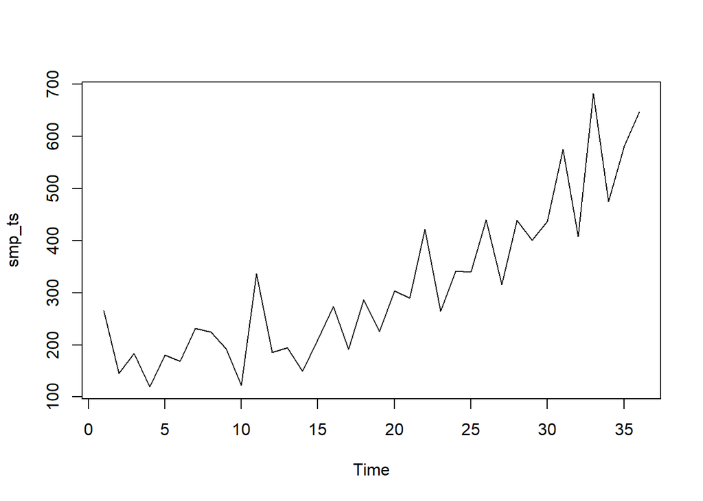

```r
plot(smp_ts)
```

### 5. Stationarity in Time Series

Stationarity is a fundamental assumption in many time series modeling methods, including ARIMA. A stationary time series has a constant mean, variance, and autocorrelation structure over time.

Non-stationary data can lead to unreliable models because they are driven by trends or external factors rather than intrinsic patterns.

### 6. Autocorrelation and Partial Autocorrelation Functions

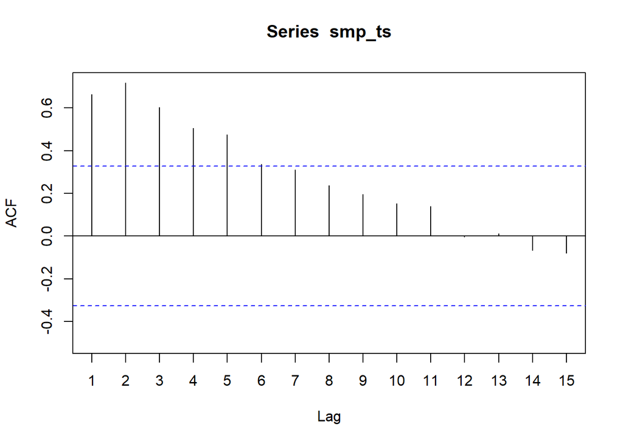

```r
Acf(smp_ts)
```

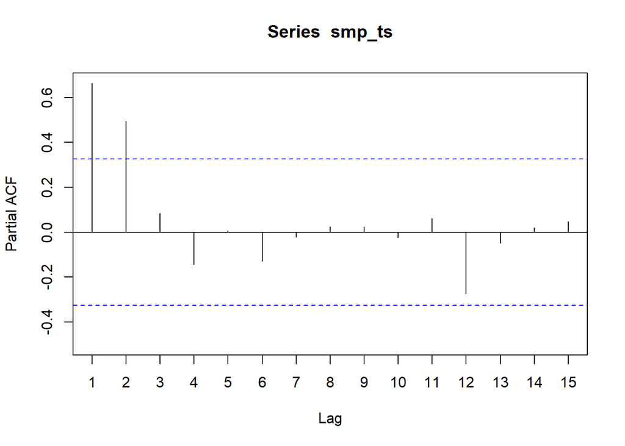

```r
Pacf(smp_ts)
```

The Autocorrelation Function (ACF) measures the correlation between the time series and its lagged versions. High autocorrelations at certain lags indicate dependence. The Partial Autocorrelation Function (PACF) isolates the correlation of a specific lag after accounting for all previous lags. This helps in identifying autoregressive (AR) terms in ARIMA models.

### 7. Augmented Dickey-Fuller (ADF) Test for Stationarity

```r
smp_ts |> adf.test()
```

```
##
##  Augmented Dickey-Fuller Test
##
## data:  smp_ts
## Dickey-Fuller = -0.93943, Lag order = 3, p-value = 0.9332
## alternative hypothesis: stationary
```

- The ADF Test evaluates the null hypothesis : “The time series is non-stationary.”
- A high p-value (`p>0.05`) means we fail to reject the null-hypothesis, confirming the series is non-stationary.
- This is expected in real-world datasets with trends or seasonality.

## Determining ARIMA Parameters (p,d,q)

The ARIMA model combines:

- Autoregressive (AR) component (p): Captures the relationship between an observation and its lagged values.
- Differencing (I) component (d): Makes the series stationary.
- Moving Average (MA) component (q): Models the relationship between an observation and the residual errors from lagged observations.

### 8. Differencing to Achieve Stationarity

Differencing removes trends or cycles in the data, stabilizing its mean and variance over time. Here, we apply first-order differencing (d=1), which calculates the difference between consecutive observations.

```r
smp_ts |> diff(differences = 1) |> adf.test()
```

```
##
##  Augmented Dickey-Fuller Test
##
## data:  diff(smp_ts, differences = 1)
## Dickey-Fuller = -5.9245, Lag order = 3, p-value = 0.01
## alternative hypothesis: stationary
```

After differencing, the ADF test confirms stationarity (p-value < 0.05). This step is critical for making the data suitable for ARIMA modeling. First differencing has given us stationary data. therefore, the d part of our model is 1.

Plotting the model for a visual interpretation.

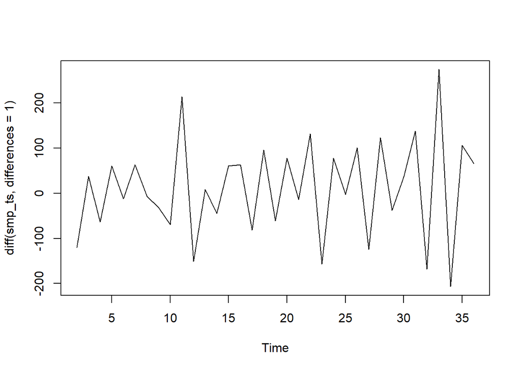

```r
smp_ts |> diff(differences = 1) |> plot()
```

**Now we determine p and q parameters with differencing 1.**

### 9. Identifying AR (p) Using PACF

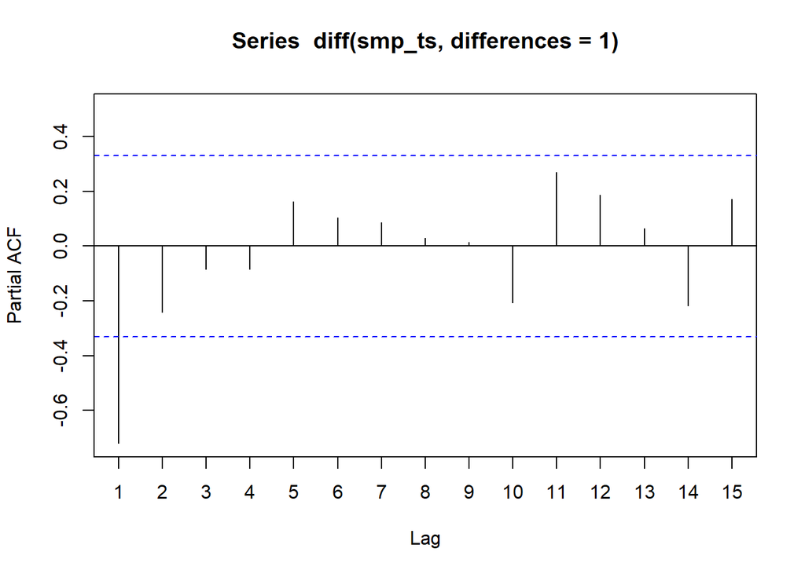

```r
Pacf(smp_ts |> diff(differences = 1))
```

In the PACF plot, significant spikes outside the confidence bounds suggest potential AR terms. The lag with the highest significant spike is chosen as p. In this case, the first lag is significant (p=1).

### 10. Identifying MA (q) Using ACF

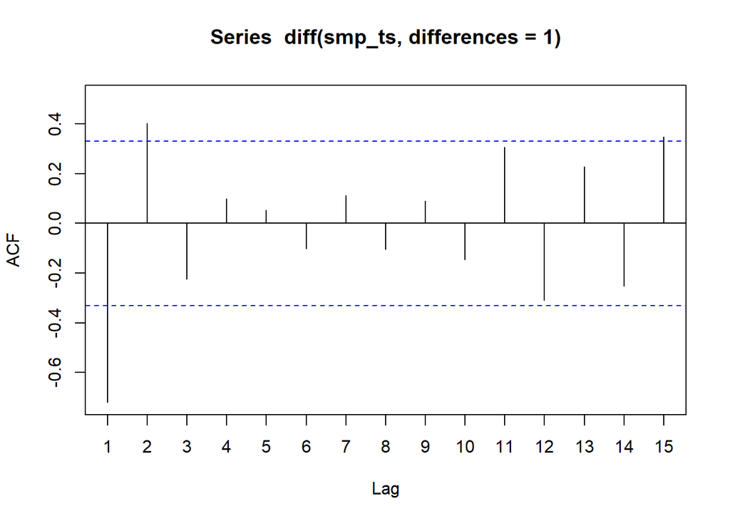

```r
Acf(smp_ts |> diff(differences = 1))
```

In the ACF plot, significant spikes indicate potential MA terms. Here, the first and second lags are significant, so q=2 is chosen.

### 11. Building the ARIMA Model

ARIMA(1,1,2) specifies p=1, d=1, and q=2.

```r
tsmod <- Arima(smp_ts, order = c(1, 1, 2))

summary(tsmod)
```

```
## Series: smp_ts
## ARIMA(1,1,2)
##
## Coefficients:
##          ar1      ma1     ma2
##       0.0902  -1.3221  1.0000
## s.e.  0.2055   0.1475  0.1631
##
## sigma^2 = 4076:  log likelihood = -196.66
## AIC=401.33   AICc=402.66   BIC=407.55
##
## Training set error measures:
##                    ME     RMSE      MAE        MPE     MAPE      MASE
## Training set 12.84715 60.19013 46.38463 -0.5750394 18.16703 0.5257836
##                       ACF1
## Training set -0.0003771582
```

The coefficients represent the relationships: ar1: Coefficient for lag 1 in the AR term.

ma1,ma2: Coefficients for lag 1 and 2 in the MA term.

## Diagnostic Analysis of the ARIMA Model

### 11. Box-Ljung Test for Residuals

The Box-Ljung Test evaluates whether the residuals from the model are independent (white noise). If the p-value is high (p>0.05), the residuals are uncorrelated, indicating a well-fitted model.

```r
Box.test(tsmod$residuals, type = "Ljung-Box")
```

```
##
##  Box-Ljung test
##
## data:  tsmod$residuals
## X-squared = 5.5599e-06, df = 1, p-value = 0.9981
```

The extremely high p-value (close to 1) suggests that the residuals are not autocorrelated. This is an excellent result, confirming that the ARIMA(1,1,2) model successfully captures all patterns in the data.

- Alternatively, `Box-Pierce` test also can be performed.

### 12. ACF and PACF of Residuals

To confirm that the residuals are white noise, we examine their ACF and PACF plots.

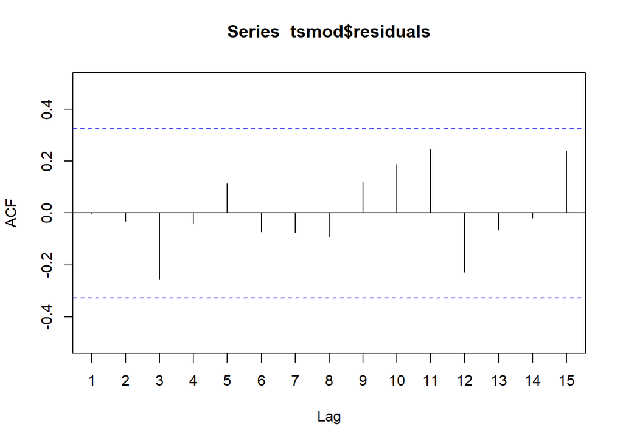

```r
Acf(tsmod$residuals)
```

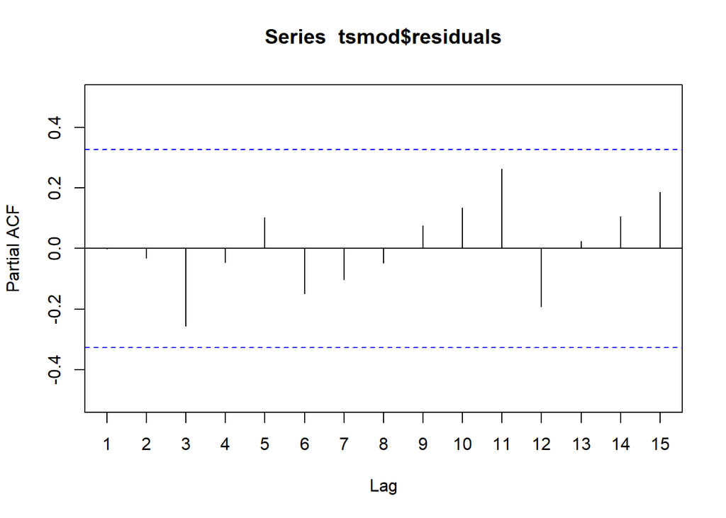

```r
Pacf(tsmod$residuals)
```

The ACF and PACF plots should show no significant spikes (all points within the confidence bounds). Lack of significant spikes confirms that the residuals have no remaining patterns, trends, or dependencies that the model failed to capture.

### 13. `checkresiduals` Function

Good residusals have no discernible pattern (white noise), and are uncorrelated (Ljung-Box test with high p-value).

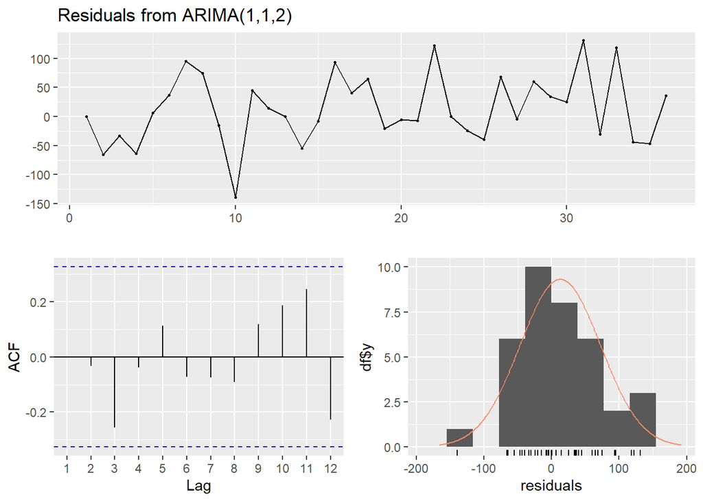

```
##
##  Ljung-Box test
##
## data:  Residuals from ARIMA(1,1,2)
## Q* = 3.8758, df = 4, p-value = 0.4231
##
## Model df: 3.   Total lags used: 7
```

```r
checkresiduals(tsmod)
```

The p value (p=0.4231) is comfortably above 0.05, affirming that the residuals are uncorrelated. The test confirms that the ARIMA(1,1,2) model adequately captures the time series structure.

### 14. Forecasting Future Values

```r
fcast <- forecast(tsmod, h = 6, bootstrap = TRUE, times = 100)
```

- The forecast function predicts future values.
- Bootstrap forecasting generates multiple simulations to create robust confidence intervals.
- The h = 6 specifies a 6-step forecast horizon. It means the forecast is done for next six times. We can specify the numbers based on our requirements.

The forecast includes: * Point Forecasts: Central predictions for future values. * Confidence Intervals (80%, 95%): Ranges where future values are likely to fall. Wider intervals indicate higher uncertainty.

### 15. Viewing the forecast results.

```r
fcast
```

```
##    Point Forecast    Lo 80    Hi 80    Lo 95    Hi 95
## 37       560.1786 491.0204 641.4276 406.6051 677.1856
## 38       586.9560 518.4177 673.7791 482.1477 706.3070
## 39       589.3702 503.2334 680.5734 457.2136 732.9055
## 40       589.5879 483.1608 699.4857 420.6311 754.7653
## 41       589.6075 471.9142 710.9663 403.4878 774.7594
## 42       589.6093 456.8820 726.8921 387.5144 798.7479
```

This provides the data for Point Forecast, Lo and Hi values for the confidence interval. The point forecast data means the actual values forecasted by the model.

### 16. Plotting the forecasted result

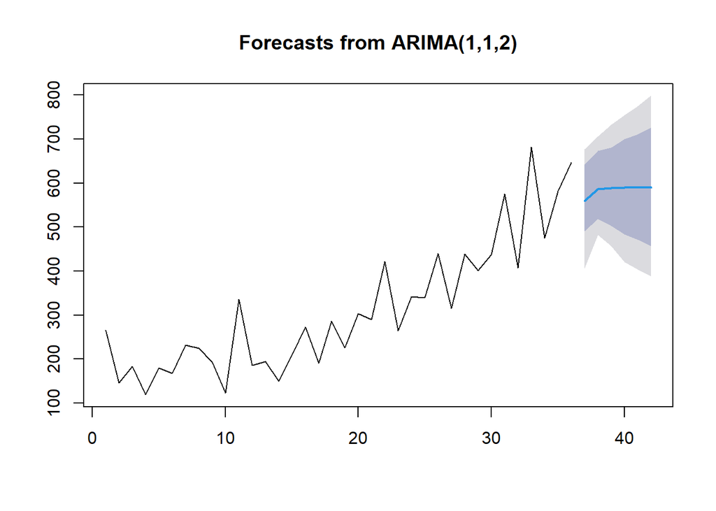

```r
plot(fcast)
```

### 17. Testing the accuracy of the model

```r
accuracy(fcast)
```

```
##                    ME     RMSE      MAE        MPE     MAPE      MASE
## Training set 12.84715 60.19013 46.38463 -0.5750394 18.16703 0.5257836
##                       ACF1
## Training set -0.0003771582
```

### 18. Plotting the predicted line and original line.

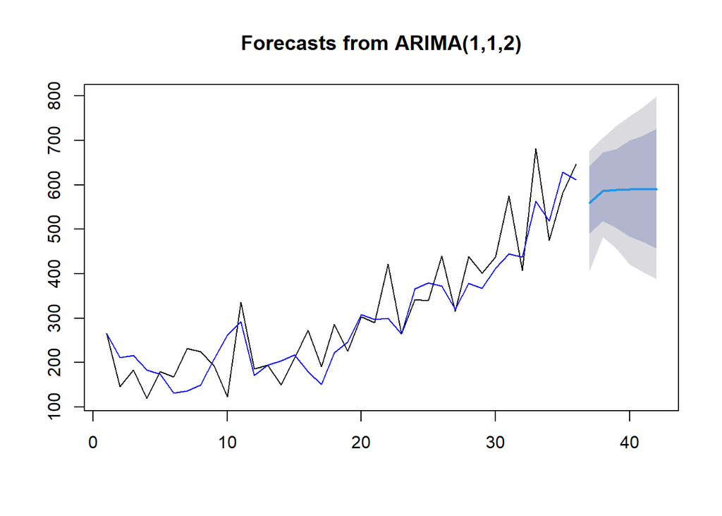

```r
plot(fcast, col = "black")
lines(fitted(fcast), col = "blue")
```

**Note: the accuracy assessment and all the stuffs are done in the forecasted result in the other tutorial. It doesn’t matter if we do the assessment in the model residuals or the forecast residuals. The residuals are the same in both.**